# Análise descritiva para epidemiologia de COVID-19 em colaboradores do HPP

Marielen Ribeiro, Carolina Prando e [Henrique Laureano](https://henriquelaureano.github.io/)

Last modification on* 2022-07-19 18:53:55

# Bloco 1

> **Nexo epidemiológico: perguntas respondidas em questionário de investigação feito pelo SESMT**

## Função/Cargo

```
                                      funcao_1   n   perc
1                                   Enfermagem 215 46.14%
2                               Administrativo  35  7.51%
3                             Servente Limpeza  35  7.51%
4                              Recepcionista I  15  3.22%
5                          Servente Lavanderia  12  2.58%
6                            Auxiliar Farmacia  11  2.36%
7                                      Copeira  11  2.36%
8                                Estagiario(a)  11  2.36%
9                      Orientador de Seguranca   6  1.29%
10                      Tecnico de Laboratorio   6  1.29%
11                     Analista de Laboratorio   5  1.07%
12                            Auxiliar Cozinha   5  1.07%
13                                   Coletador   5  1.07%
14                                Lactarista I   5  1.07%
```

[output cut: 63 more lines]

## Data de início dos sintomas

```
      Mínimo   1o.quantil      Mediana        Média   3o.quantil       Máximo         NA's
"2020-06-01" "2020-08-11" "2020-11-22" "2020-11-23" "2021-02-18" "2021-12-10"         "13"
```

```
Desvio.Padrão
     104.4614
```

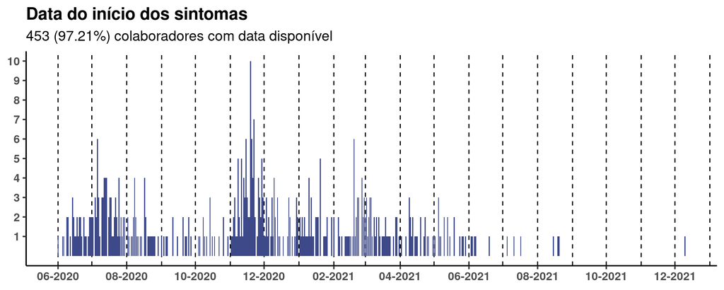

## Data do resultado positivo

```
      Mínimo   1o.quantil      Mediana        Média   3o.quantil       Máximo
"2020-04-04" "2020-08-12" "2020-11-26" "2020-11-26" "2021-02-19" "2021-12-11"
```

```
Desvio.Padrão
     105.3171
```

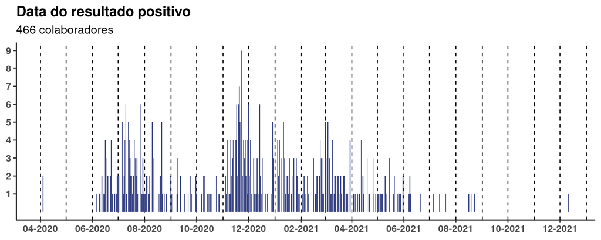

## Dias do início dos sintomas até o resultado positivo

```
        Mínimo     1o.quantil        Mediana          Média     3o.quantil         Máximo
         0.000          1.000          3.000          2.832          4.000         14.000
Não.Disponível  Desvio.Padrão
        13.000          1.919
```

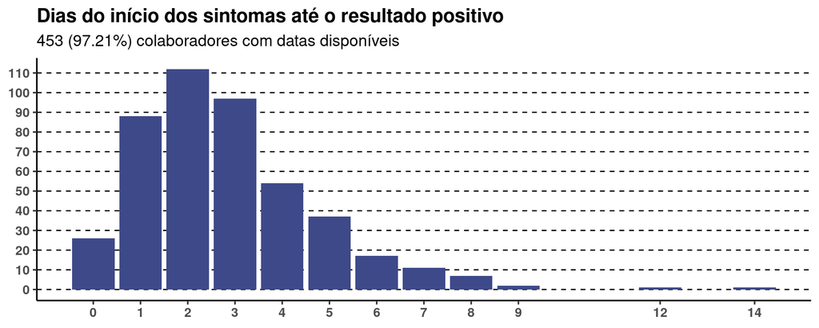

```
   [,1]    [,2]
   "Total" "Percentual"
0  "26"    "5.74%"
1  "88"    "19.426%"
2  "112"   "24.724%"
3  "97"    "21.413%"
4  "54"    "11.921%"
5  "37"    "8.168%"
6  "17"    "3.753%"
7  "11"    "2.428%"
8  "7"     "1.545%"
9  "2"     "0.442%"
12 "1"     "0.221%"
14 "1"     "0.221%"
```

## Atividade administrativa?

```
                  Não       Sim
[1,] "Total"      "319"     "146"
[2,] "Percentual" "68.602%" "31.398%"
```

> Com um valor-p altamente significativo ($\chi^{2}$ = 326.35, valor-p < 0.0001), essa diferença é estatisticamente significativa.

## Assistência direta a pessoas suspeitas ou confirmadas de COVID-19?

```
                  Não       Sim
[1,] "Total"      "365"     "100"
[2,] "Percentual" "78.495%" "21.505%"
```

> Com um valor-p altamente significativo ($\chi^{2}$ = 456.06, valor-p < 0.0001), essa diferença é estatisticamente significativa.

## Utiliza EPI habitualmente e corretamente?

```
                  Não      Sim
[1,] "Total"      "25"     "439"
[2,] "Percentual" "5.388%" "94.612%"
```

> Com um valor-p altamente significativo ($\chi^{2}$ = 778.74, valor-p < 0.0001), essa diferença é estatisticamente significativa.

## Treinamento de uso e/ou paramentação e desparamentação de EPIs?

```
                  Não      Sim
[1,] "Total"      "87"     "377"
[2,] "Percentual" "18.75%" "81.25%"
```

> Com um valor-p altamente significativo ($\chi^{2}$ = 497.75, valor-p < 0.0001), essa diferença é estatisticamente significativa.

## Colaborador com Covid-19 nos setores que laborou nos últimos 15 dias?

```
                  Não       Sim
[1,] "Total"      "336"     "129"
[2,] "Percentual" "72.258%" "27.742%"
```

> Com um valor-p altamente significativo ($\chi^{2}$ = 367.94, valor-p < 0.0001), essa diferença é estatisticamente significativa.

## Trabalha em outra instituição hospitalar?

```
                  Não       Sim
[1,] "Total"      "357"     "108"
[2,] "Percentual" "76.774%" "23.226%"
```

> Com um valor-p altamente significativo ($\chi^{2}$ = 429.58, valor-p < 0.0001), essa diferença é estatisticamente significativa.

## Assistência direta a pessoas suspeitas ou confirmadas de COVID-19?

```
                  Não       Não informado Sim
[1,] "Total"      "66"      "357"         "43"
[2,] "Percentual" "14.163%" "76.609%"     "9.227%"
```

```
                  Não      Sim
[1,] "Total"      "66"     "43"
[2,] "Percentual" "60.55%" "39.45%"
```

> Com um valor-p significativo ($\chi^{2}$ = 4.85, valor-p = 0.0276), essa diferença é estatisticamente significativa.

## Utiliza EPI habitualmente e corretamente?

```
                  Não      Não informado Sim
[1,] "Total"      "3"      "439"         "24"
[2,] "Percentual" "0.644%" "94.206%"     "5.15%"
```

```
                  Não       Sim
[1,] "Total"      "3"       "24"
[2,] "Percentual" "11.111%" "88.889%"
```

> Com um valor-p significativo ($\chi^{2}$ = 16.34, valor-p < 0.0001), essa diferença é estatisticamente significativa.

## Recebeu treinamento de paramentação e desparamentação de EPIs?

```
                  Não      Não informado Sim
[1,] "Total"      "8"      "439"         "19"
[2,] "Percentual" "1.717%" "94.206%"     "4.077%"
```

```
                  Não      Sim
[1,] "Total"      "8"      "19"
[2,] "Percentual" "29.63%" "70.37%"
```

> Com um valor-p significativo ($\chi^{2}$ = 4.48, valor-p = 0.0343), essa diferença é estatisticamente significativa.

## Colaborador com Covid-19 nos setores que laborou nos últimos 15 dias?

```
                  Não      Não informado Sim
[1,] "Total"      "25"     "439"         "2"
[2,] "Percentual" "5.365%" "94.206%"     "0.429%"
```

```
                  Não       Sim
[1,] "Total"      "25"      "2"
[2,] "Percentual" "92.593%" "7.407%"
```

> Com um valor-p altamente significativo ($\chi^{2}$ = 19.6, valor-p < 0.0001), essa diferença é estatisticamente significativa.

## Das pessoas que moram com você/convivência cotidiana, alguma apresentou síndrome gripal nas últimas semanas ou confirmação de COVID-19?

```
                  Não       Não informado Sim
[1,] "Total"      "227"     "1"           "238"
[2,] "Percentual" "48.712%" "0.215%"      "51.073%"
```

> Com um valor-p não significativo ($\chi^{2}$ = 0.26, valor-p = 0.61), essa diferença é estatisticamente não significativa.

## Mora com alguém que trabalha na área assistencial ou ambiente de saúde?

```
                  Não       Não informado Sim
[1,] "Total"      "403"     "2"           "61"
[2,] "Percentual" "86.481%" "0.429%"      "13.09%"
```

> Com um valor-p altamente significativo ($\chi^{2}$ = 252.1, valor-p < 0.0001), essa diferença é estatisticamente significativa.

## Mora com alguém que trabalha em atividade essencial?

```
                  Não       Não informado Sim
[1,] "Total"      "397"     "2"           "67"
[2,] "Percentual" "85.193%" "0.429%"      "14.378%"
```

> Com um valor-p altamente significativo ($\chi^{2}$ = 234.7, valor-p < 0.0001), essa diferença é estatisticamente significativa.

## Recebeu visitas ou visitou nos últimos 15 dias?

```
                  Não       Não informado Sim
[1,] "Total"      "288"     "1"           "177"
[2,] "Percentual" "61.803%" "0.215%"      "37.983%"
```

## Frequentou, nos últimos 15 dias, supermercados/farmácias/comércios?

```
                  Não      Não informado Sim
[1,] "Total"      "85"     "1"           "380"
[2,] "Percentual" "18.24%" "0.215%"      "81.545%"
```

> Com um valor-p altamente significativo ($\chi^{2}$ = 187.15, valor-p < 0.0001), essa diferença é estatisticamente significativa.

## Participou de algum evento social ou conviveu com outras pessoas fora de seu grupo familiar e de trabalho estrito nos últimos 15 dias?

```
                  Não      Não informado Sim
[1,] "Total"      "442"    "1"           "23"
[2,] "Percentual" "94.85%" "0.215%"      "4.936%"
```

> Com um valor-p altamente significativo ($\chi^{2}$ = 377.55, valor-p < 0.0001), essa diferença é estatisticamente significativa.

## Participou de eventos religiosos nos últimos 15 dias?

```
                  Não       Não informado Sim
[1,] "Total"      "421"     "1"           "44"
[2,] "Percentual" "90.343%" "0.215%"      "9.442%"
```

> Com um valor-p altamente significativo ($\chi^{2}$ = 305.65, valor-p < 0.0001), essa diferença é estatisticamente significativa.

## Fora do ambiente de trabalho, seguiu, nos últimos 15 dias, as práticas de distanciamento social e profilaxia?

```
                  Não      Não informado Sim
[1,] "Total"      "4"      "1"           "461"
[2,] "Percentual" "0.858%" "0.215%"      "98.927%"
```

> Com um valor-p altamente significativo ($\chi^{2}$ = 449.14, valor-p < 0.0001), essa diferença é estatisticamente significativa.

## Nos últimos 15 dias, passou por outra avaliação de saúde em procedimento ambulatorial ou de consultório, ainda que por motivos alheios ao COVID-19?

```
                  Não      Não informado Sim
[1,] "Total"      "379"    "1"           "86"
[2,] "Percentual" "81.33%" "0.215%"      "18.455%"
```

> Com um valor-p altamente significativo ($\chi^{2}$ = 184.62, valor-p < 0.0001), essa diferença é estatisticamente significativa.

## Transporte coletivo para trabalhar ou para retornar do trabalho?

```
                  Não       Não informado Sim
[1,] "Total"      "200"     "1"           "265"
[2,] "Percentual" "42.918%" "0.215%"      "56.867%"
```

> Com um valor-p significativo ($\chi^{2}$ = 9.09, valor-p = 0.0026), essa diferença é estatisticamente significativa.

# Bloco 2

> **EPI: equipamentos de proteção individual relatados pelos colaboradores**

```
              EPI Não Sim   n  Não.prop   Sim.prop statistic.X-squared      p.value
1    mascara_desc 324 142 466 0.6952790 0.30472103            71.08155 3.427613e-17
2             N95 191 275 466 0.4098712 0.59012876            15.14163 9.973945e-05
3  mascara_tecido 382  84 466 0.8197425 0.18025751           190.56652 2.391510e-43
4     face_shield 286 180 466 0.6137339 0.38626609            24.11159 9.091158e-07
5         avental 285 181 466 0.6115880 0.38841202            23.21030 1.452174e-06
6           touca 320 146 466 0.6866953 0.31330472            64.96996 7.604871e-16
7          oculos 369  97 466 0.7918455 0.20815451           158.76395 2.107255e-36
8            luva 364 102 466 0.7811159 0.21888412           147.30472 6.731598e-34
9          sapato 448  18 466 0.9613734 0.03862661           396.78112 2.764727e-88
10         pijama 347 119 466 0.7446352 0.25536481           111.55365 4.475296e-26
```

> Todas as diferenças em frequências são significativas.

> (Para exemplificar, 9.97e-05 = 0.0000997)

[figure not shown]

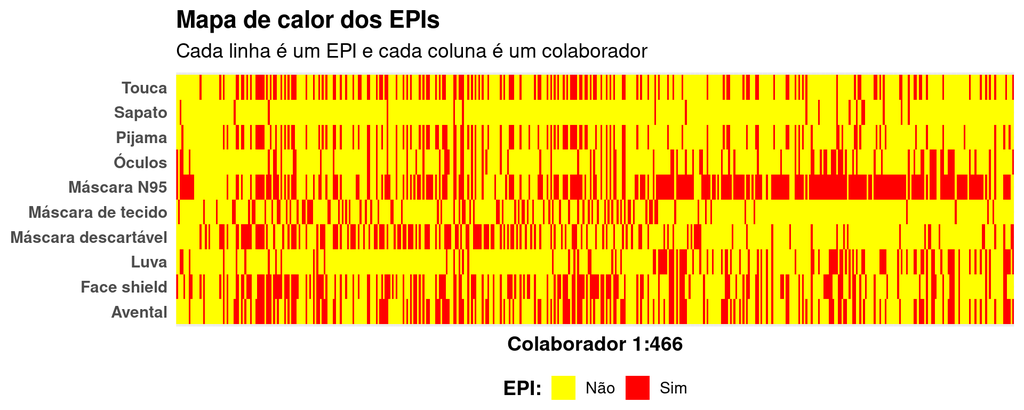

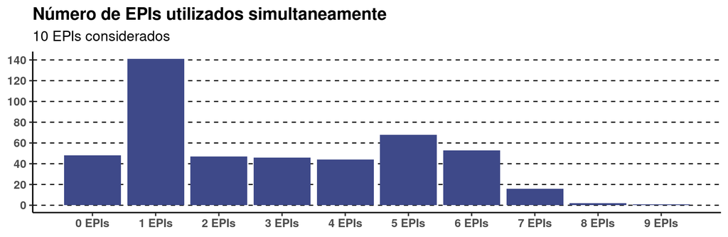

```
  [,1]    [,2]
  "Total" "Percentual"
0 "48"    "10.3%"
1 "141"   "30.258%"
2 "47"    "10.086%"
3 "46"    "9.871%"
4 "44"    "9.442%"
5 "68"    "14.592%"
6 "53"    "11.373%"
7 "16"    "3.433%"
8 "2"     "0.429%"
9 "1"     "0.215%"
```

> Combinações de EPIs mais frequentes:

```
# A tibble: 14 × 3
   EPIs                                                                     n   prop
   <chr>                                                                <int>  <dbl>
 1 N95                                                                     54 0.116
 2 mascara_tecido                                                          46 0.0987
 3 mascara_desc                                                            41 0.0880
 4 mascara_desc + N95 + face_shield + avental + touca + pijama             23 0.0494
 5 N95 + face_shield + avental + touca + pijama                            18 0.0386
 6 mascara_tecido + face_shield                                            15 0.0322
 7 N95 + face_shield + avental + oculos + luva                             12 0.0258
 8 N95 + face_shield                                                       10 0.0215
 9 mascara_desc + N95 + face_shield + avental + touca + oculos + pijama     9 0.0193
10 N95 + face_shield + avental + luva                                       8 0.0172
11 N95 + face_shield + avental + touca + oculos + pijama                    8 0.0172
12 N95 + avental + oculos + luva                                            7 0.0150
13 N95 + face_shield + oculos                                               5 0.0107
14 N95 + oculos + luva                                                      5 0.0107
```

# Bloco 3

> **Sintomas de fase aguda: pesquisa em prontuário**

```
                  Sintoma Não Sim   n  Não.prop    Sim.prop statistic.X-squared       p.value
1           Assintomático 445  21 466 0.9549356 0.045064378          385.785408  6.845603e-86
2                Cefaléia 188 278 466 0.4034335 0.596566524           17.381974  3.057116e-05
3                Diarreia 403  63 466 0.8648069 0.135193133          248.068670  6.846893e-56
4                   Tosse 296 170 466 0.6351931 0.364806867           34.068670  5.320100e-09
5                   Febre 370  96 466 0.7939914 0.206008584          161.107296  6.482201e-37
6         Dor de garganta 297 169 466 0.6373391 0.362660944           35.158798  3.038853e-09
7            Dor muscular 250 216 466 0.5364807 0.463519313            2.480687  1.152519e-01
8         Perda de olfato 374  92 466 0.8025751 0.197424893          170.652361  5.329494e-39
9        Perda de paladar 385  81 466 0.8261803 0.173819742          198.317597  4.863821e-45
10          Náusea/Vômito 411  55 466 0.8819742 0.118025751          271.965665  4.231621e-61
11               Dispnéia 422  44 466 0.9055794 0.094420601          306.618026  1.191181e-68
12                 Coriza 307 159 466 0.6587983 0.341201717           47.004292  7.083143e-12
13         Sintoma ocular 412  54 466 0.8841202 0.115879828          275.030043  9.092222e-62
14               Sudorese 448  18 466 0.9613734 0.038626609          396.781116  2.764727e-88
15            Inapetência 428  38 466 0.9184549 0.081545064          326.394850  5.861473e-73
16           Dor no peito 437  29 466 0.9377682 0.062231760          357.218884  1.135456e-79
17               Tremores 463   3 466 0.9935622 0.006437768          454.077253 9.349777e-101
18 Fadiga/Astenia/Cansaço 405  61 466 0.8690987 0.130901288          253.939914  3.593595e-57
19              Dorsalgia 432  34 466 0.9270386 0.072961373          339.922747  6.632771e-76
20              Congestão 406  60 466 0.8712446 0.128755365          256.901288  8.127870e-58
21               Espirros 422  44 466 0.9055794 0.094420601          306.618026  1.191181e-68
22               Calafrio 432  34 466 0.9270386 0.072961373          339.922747  6.632771e-76
23     Dor abdominal/Gast 444  22 466 0.9527897 0.047210300          382.154506  4.225662e-85
24                Otalgia 454  12 466 0.9742489 0.025751073          419.236052  3.578731e-93
25              Mal estar 454  12 466 0.9742489 0.025751073          419.236052  3.578731e-93
```

> Com exceção da dor muscular (valor-p = 0.1152), todas as (demais) diferenças são estatísticamente significativas.

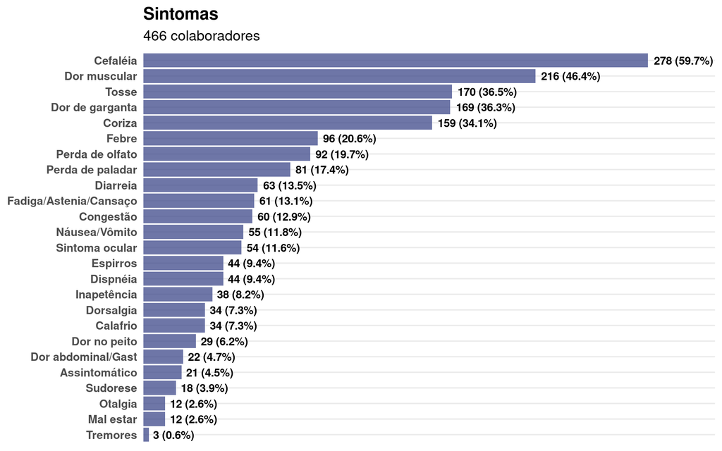

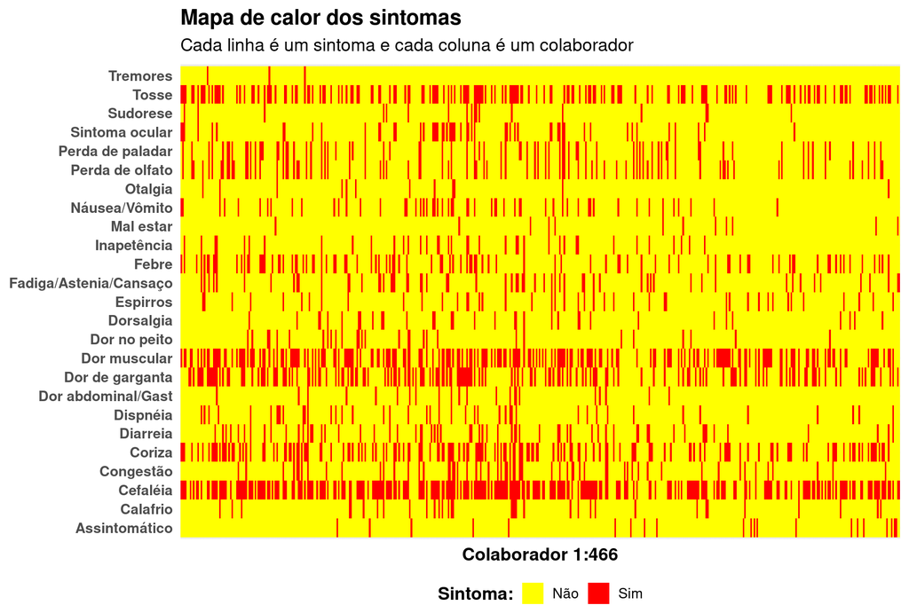

> Combinações de sintomas mais frequentes:

```
# A tibble: 16 × 3
   Sintoma                                                                       n    prop
   <chr>                                                                     <int>   <dbl>
 1 Assintomático                                                                21 0.0451
 2 Dor de garganta                                                               7 0.0150
 3 Cefaléia + Tosse + Dor muscular                                               6 0.0129
 4 Cefaléia                                                                      4 0.00858
 5 Cefaléia + Dor muscular                                                       4 0.00858
 6 Cefaléia + Dor muscular + Coriza                                              4 0.00858
 7 Cefaléia + Tosse                                                              4 0.00858
 8 Cefaléia + Tosse + Dor muscular + Coriza                                      4 0.00858
 9 Dor de garganta + Dor muscular                                                4 0.00858
10 Perda de olfato + Perda de paladar                                            4 0.00858
11 Cefaléia + Dor de garganta                                                    3 0.00644
12 Cefaléia + Dor de garganta + Dor muscular                                     3 0.00644
13 Cefaléia + Febre + Dor muscular                                               3 0.00644
14 Cefaléia + Tosse + Dor de garganta                                            3 0.00644
15 Cefaléia + Tosse + Febre + Dor de garganta + Dor muscular + Náusea/Vômito     3 0.00644
16 Dor de garganta + Dor muscular + Coriza + Espirros                            3 0.00644
```

```
        Mínimo     1o.quantil        Mediana          Média     3o.quantil         Máximo
          0.00          10.00          14.00          12.54          14.00          24.00
Não.Disponível  Desvio.Padrão
          7.00           3.30
```

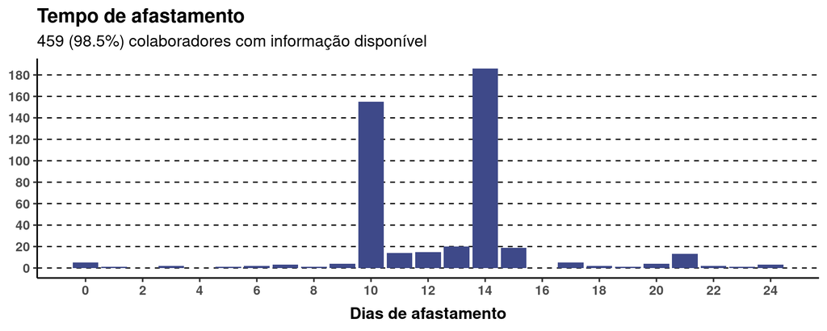

```
   [,1]    [,2]
   "Total" "Percentual"
0  "5"     "1.089%"
1  "1"     "0.218%"
3  "2"     "0.436%"
5  "1"     "0.218%"
6  "2"     "0.436%"
7  "3"     "0.654%"
8  "1"     "0.218%"
9  "4"     "0.871%"
10 "155"   "33.769%"
11 "14"    "3.05%"
12 "15"    "3.268%"
13 "20"    "4.357%"
14 "186"   "40.523%"
15 "19"    "4.139%"
17 "5"     "1.089%"
18 "2"     "0.436%"
19 "1"     "0.218%"
20 "4"     "0.871%"
21 "13"    "2.832%"
22 "2"     "0.436%"
23 "1"     "0.218%"
24 "3"     "0.654%"
```

```
# A tibble: 7 × 3
  Outros           n    prop
  <chr>        <int>   <dbl>
1 Artralgia        4 0.00858
2 Odinofagia       4 0.00858
3 Tontura          3 0.00644
4 gosto amargo     2 0.00429
5 hipotermia       2 0.00429
6 pigarro          2 0.00429
7 taquicardia      2 0.00429
```

> **Internação**

```
                  Não       Sim
[1,] "Total"      "463"     "3"
[2,] "Percentual" "99.356%" "0.644%"
```

> Com um valor-p significativo ($\chi^{2}$ = 454.08, valor-p < 0.0001), essa diferença é estatisticamente significativa.

> **Reinfecção**

```
                  Não       Sim
[1,] "Total"      "445"     "21"
[2,] "Percentual" "95.494%" "4.506%"
```

> Com um valor-p significativo ($\chi^{2}$ = 385.78, valor-p < 0.0001), essa diferença é estatisticamente significativa.

> Combinações:

```
  internacao reinfeccao   n
1        Não        Não 442
2        Não        Sim  21
3        Sim        Não   3
```

# Bloco 4

> **Sintomas de longo prazo / recorte longitudinal: aplicação de questionário**

```
           Sintoma Não Sim   n  Não.prop   Sim.prop statistic.X-squared      p.value
1 Perda de paladar 120  11 131 0.9160305 0.08396947            90.69466 1.676454e-21
2  Perda de olfato 119  12 131 0.9083969 0.09160305            87.39695 8.878746e-21
3         Cefaléia 112  19 131 0.8549618 0.14503817            66.02290 4.457141e-16
4     Dor muscular 108  23 131 0.8244275 0.17557252            55.15267 1.115220e-13
5          Cansaço 128   3 131 0.9770992 0.02290076           119.27481 9.118055e-28
6         Dispnéia 120  11 131 0.9160305 0.08396947            90.69466 1.676454e-21
7  Dor de garganta 125   6 131 0.9541985 0.04580153           108.09924 2.556520e-25
8         Confusão 123   8 131 0.9389313 0.06106870           100.95420 9.413518e-24
```

> Todas as diferenças são estatisticamente significativas.

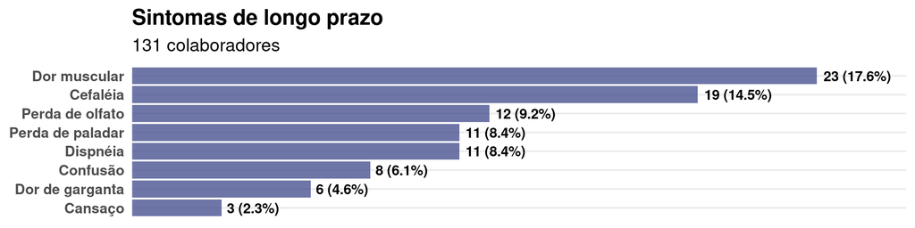

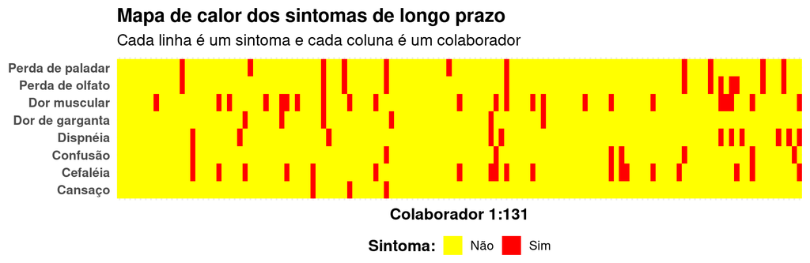

> Combinações de sintomas de longo prazo mais frequentes:

```
# A tibble: 9 × 3
  Sintoma                                       n   prop
  <chr>                                     <int>  <dbl>
1 Cefaléia + Dor muscular                       6 0.0458
2 Dispnéia                                      6 0.0458
3 Dor muscular                                  6 0.0458
4 Perda de paladar + Perda de olfato            5 0.0382
5 Cefaléia + Dor muscular + Confusão            3 0.0229
6 Cefaléia                                      2 0.0153
7 Dor muscular + Dor de garganta                2 0.0153
8 Perda de olfato + Dor muscular + Dispnéia     2 0.0153
9 Perda de paladar                              2 0.0153
```

```
# A tibble: 18 × 3
   Outros                                          n    prop
   <chr>                                       <int>   <dbl>
 1 Falta de ar                                     2 0.0153
 2 Anemia                                          1 0.00763
 3 Diarreia                                        1 0.00763
 4 Esquecimento                                    1 0.00763
 5 Fadiga                                          1 0.00763
 6 Falta de ar e tosse                             1 0.00763
 7 Falta de concentração                           1 0.00763
 8 falta de memória                                1 0.00763
 9 Falta de memória                                1 0.00763
10 Febre, diarreia                                 1 0.00763
11 Mal estar                                       1 0.00763
12 Nausea/vomitos                                  1 0.00763
13 perda de memória                                1 0.00763
14 Perda de memória, queda de cabelo               1 0.00763
15 Sinusite, dor lombar, desconforto abdominal     1 0.00763
16 Sinusite, dor nas costas                        1 0.00763
17 tontura                                         1 0.00763
18 Tontura, raciocínio lento                       1 0.00763
```

## Há quanto tempo você trabalha na área da saúde?

```
                  Até 5 anos 5 à 9 anos 10 à 14 anos 15 à 20 anos Mais de 20 anos
[1,] "Total"      "55"       "30"       "19"         "14"         "13"
[2,] "Percentual" "41.985%"  "22.901%"  "14.504%"    "10.687%"    "9.924%"
```

> Com um valor-p altamente significativo ($\chi^{2}$ = 46.52, valor-p < 0.0001), as diferenças são estatisticamente significativas.

## Você apresentou uma segunda infecção pela COVID 19?

```
                  Não       Sim
[1,] "Total"      "118"     "13"
[2,] "Percentual" "90.076%" "9.924%"
```

> Com um valor-p altamente significativo ($\chi^{2}$ = 84.16, valor-p < 0.0001), essa diferença é estatisticamente significativa.

## Desde o seu quadro de COVID-19, você se sente totalmente recuperado?

```
                  Não       Sim
[1,] "Total"      "58"      "73"
[2,] "Percentual" "44.275%" "55.725%"
```

> Com um valor-p não significativo ($\chi^{2}$ = 1.718, valor-p = 0.19), essa diferença não é estatisticamente significativa.

## Comparando sintomas durante e longo prazo

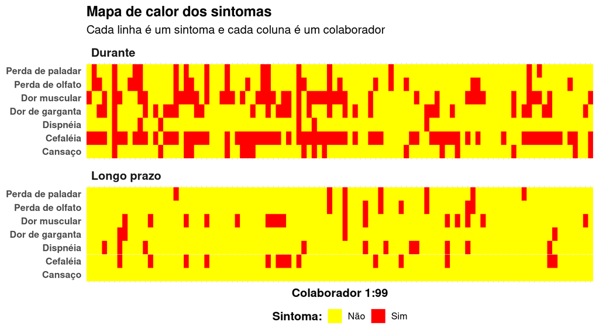

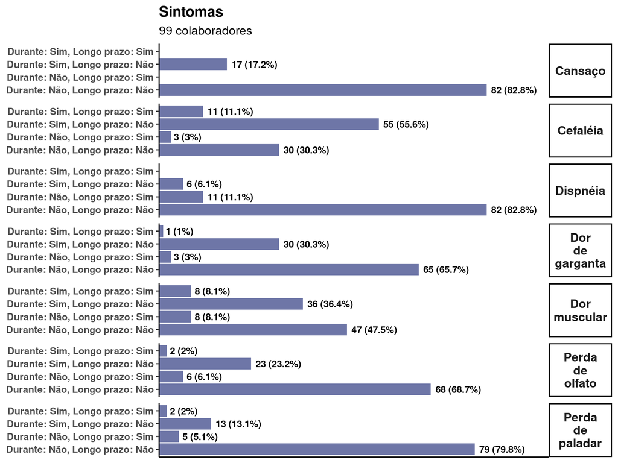

# Bloco 5

> **Comorbidades: pesquisa em prontuário**

```
      Comorbidade Não Sim   n  Não.prop    Sim.prop statistic.X-squared       p.value
1    Comorbidades 397  57 454 0.8744493 0.125550661            605.6088 3.116893e-132
2        Diabetes 448   7 455 0.9846154 0.015384615            427.4308  5.889586e-95
3             HAS 427  28 455 0.9384615 0.061538462            349.8923  4.472920e-78
4 Hipotireoidismo 446   9 455 0.9802198 0.019780220            419.7121  2.819121e-93
5       Obesidade 453   2 455 0.9956044 0.004395604            447.0352  3.186768e-99
6            Asma 443  12 455 0.9736264 0.026373626            408.2659  8.741582e-91
```

> Todas as diferenças são estatísticamente significativas.

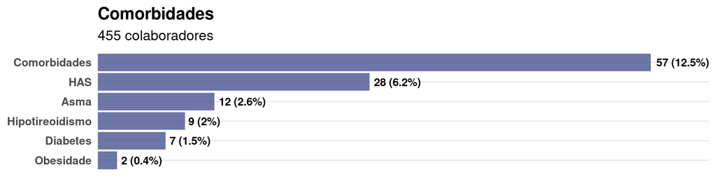

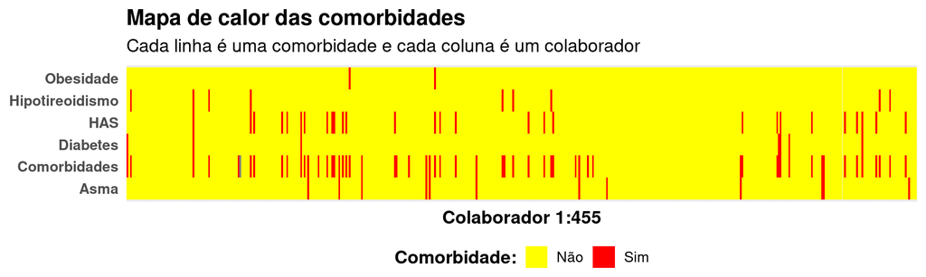

> Combinações de comorbidades:

```
# A tibble: 11 × 3
   Comorbidade                                         n    prop
   <chr>                                           <int>   <dbl>
 1 Comorbidades + HAS                                 22 0.0484
 2 Comorbidades + Asma                                10 0.0220
 3 Comorbidades                                        8 0.0176
 4 Comorbidades + Hipotireoidismo                      7 0.0154
 5 Comorbidades + Diabetes                             3 0.00659
 6 Comorbidades + Diabetes + HAS                       3 0.00659
 7 Asma                                                2 0.00440
 8 Comorbidades + Diabetes + HAS + Hipotireoidismo     1 0.00220
 9 Comorbidades + HAS + Hipotireoidismo                1 0.00220
10 Comorbidades + HAS + Obesidade                      1 0.00220
11 Comorbidades + Obesidade                            1 0.00220
```

```
# A tibble: 8 × 3
  Outros                               n    prop
  <chr>                            <int>   <dbl>
1 Bronquite                            2 0.00440
2 Bronquite crônica                    2 0.00440
3 Adenoma de hipófise                  1 0.00220
4 Artrite, depressão                   1 0.00220
5 Colite, arritmia, tireoidectomia     1 0.00220
6 Doença autoimune                     1 0.00220
7 Hipercolesterolemia                  1 0.00220
8 TEP                                  1 0.00220
```

# Bloco 6

> **Reinfecção**

> Frequências de cada sintoma.

```
# A tibble: 23 × 7
   Sintoma                `1a infecção` `2a infecção` `1a.prop` `2a.prop` `statistic.X-squ…` p.value
   <chr>                          <int>         <int>     <dbl>     <dbl>              <dbl>   <dbl>
 1 Assintomático                      4             3    0.190     0.143               0.143   0.705
 2 Calafrio                           4             1    0.190     0.0476              1.8     0.180
 3 Cefaléia                          13             8    0.619     0.381               1.19    0.275
 4 Congestão                          4             1    0.190     0.0476              1.8     0.180
 5 Coriza                            10             6    0.476     0.286               1       0.317
 6 Diarreia                           4             3    0.190     0.143               0.143   0.705
 7 Dispnéia                           2             3    0.0952    0.143               0.2     0.655
 8 Dor abdominal/Gast                 2             1    0.0952    0.0476              0.333   0.564
 9 Dor de garganta                   10             7    0.476     0.333               0.529   0.467
10 Dor muscular                      10             5    0.476     0.238               1.67    0.197
11 Dor no peito                       0             2    0         0.0952              2       0.157
12 Dorsalgia                          1             0    0.0476    0                   1       0.317
13 Espirros                           1             3    0.0476    0.143               1       0.317
14 Fadiga/Astenia/Cansaço             4             4    0.190     0.190               0       1
15 Febre                              5             2    0.238     0.0952              1.29    0.257
16 Inapetência                        1             0    0.0476    0                   1       0.317
17 Mal estar                          0             2    0         0.0952              2       0.157
18 Náusea/Vômito                      1             3    0.0476    0.143               1       0.317
19 Perda de olfato                    5             2    0.238     0.0952              1.29    0.257
20 Perda de paladar                   3             1    0.143     0.0476              1       0.317
21 Sintoma ocular                     3             2    0.143     0.0952              0.2     0.655
22 Sudorese                           1             0    0.0476    0                   1       0.317
23 Tosse                              9             9    0.429     0.429               0       1
```

> Nenhuma frequência de 1a para 2a infecção difere estatisticamente. Isso pode ser explicado pelo baixo tamanho amostral e por nenhuma diferença “ser grande”.

> Abaixo olhamos para as frequências de uma outra maneira.

```
# A tibble: 23 × 4
   Sintoma                `Apenas 1a` `Apenas 2a` `Em ambas`
   <chr>                        <int>       <int>      <int>
 1 Assintomático                    4           3          0
 2 Calafrio                         4           1          0
 3 Cefaléia                         7           2          6
 4 Congestão                        4           1          0
 5 Coriza                           7           3          3
 6 Diarreia                         4           3          0
 7 Dispnéia                         2           3          0
 8 Dor abdominal/Gast               2           1          0
 9 Dor de garganta                  7           4          3
10 Dor muscular                     8           3          2
11 Dor no peito                     0           2          0
12 Dorsalgia                        1           0          0
13 Espirros                         1           3          0
14 Fadiga/Astenia/Cansaço           4           4          0
15 Febre                            5           2          0
16 Inapetência                      1           0          0
17 Mal estar                        0           2          0
18 Náusea/Vômito                    0           2          1
19 Perda de olfato                  5           2          0
20 Perda de paladar                 3           1          0
21 Sintoma ocular                   3           2          0
22 Sudorese                         1           0          0
23 Tosse                            3           3          6
```

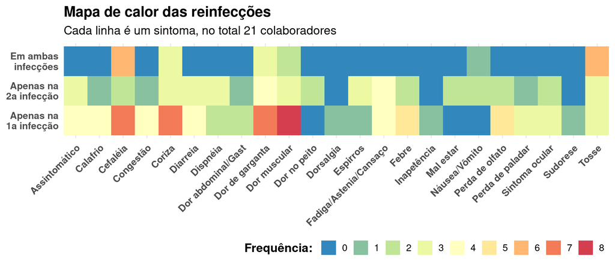

```
# A tibble: 3 × 2
  Outros                      n
  <chr>                   <int>
1 Formigamento mãos e pés     1
2 NA                         40
3 Sonolência                  1
```

> Tempos de afastamento.

```
       Mínimo    1o.quantil       Mediana         Média    3o.quantil        Máximo Desvio.Padrão
     0.000000     10.000000     12.000000     11.500000     14.000000     21.000000      3.677552
```

> Estratificando tempos por reinfecção.

```
# A tibble: 2 × 8
  Infecção Mínimo `1o.quantil` Mediana Média            `3o.quantil` Máximo Desvio.Padrão
  <chr>    <chr>  <chr>        <chr>   <chr>            <chr>        <chr>  <chr>
1 1a       0      10           14      12.2857142857143 14           21     4.11269810638779
2 2a       0      10           10      10.7142857142857 13           14     3.08452357979084
```

```
# A tibble: 1 × 7
  `1a infecção` `2a infecção` Diferença conf.low conf.high `Estatística-t` `valor-p`
          <dbl>         <dbl>     <dbl>    <dbl>     <dbl>           <dbl>     <dbl>
1          12.3          10.7      1.57   -0.701      3.84            1.40     0.170
```

> Diferença média dos tempos de afastamento da 1a para 2a reinfecção não diferem estatisticamente.

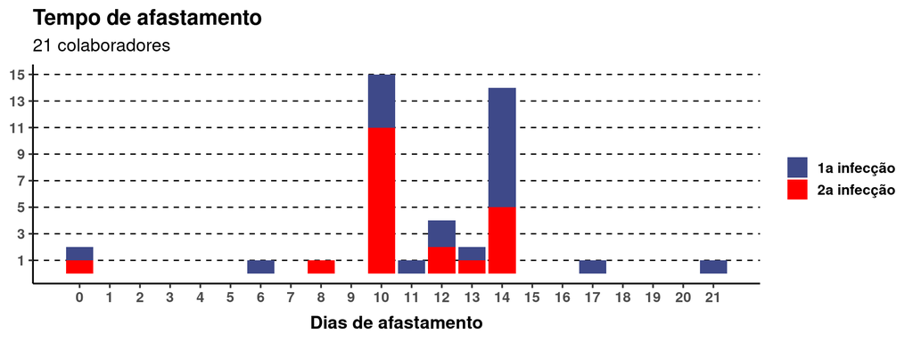

# Referências

> A análise estatística foi realizada no ambiente de computação estatística `R` (R Core Team, 2022). Os principais pacotes `R` utilizados foram o {`readxl`} (Wickham & Bryan, 2022), {`dplyr`} (Wickham et al., 2022), {`tidyr`} (Wickham & Girlich, 2022), {`ggplot2`} (Wickham, 2016), {`purrr`} (Henry & Wickham, 2020), {`haven`} (Wickham et al., 2022) e {`broom`} (Robinson et al., 2022).

> As diferenças entre frequências foram avaliadas via Teste Qui-Quadrado de *Pearson* (Patefield, 1981; Agresti, 2007) e as diferenças entre médias foram avaliadas via Teste-*t* de *Student*.

> R Core Team (2022). R: A language and environment for statistical computing. R Foundation for Statistical Computing, Vienna, Austria. URL https://www.R-project.org/

> Wickham, H., Bryan, J. (2022). readxl: Read Excel Files. R package version 1.4.0, https://CRAN.R-project.org/package=readxl

> Wickham, H., François, R., Henry, L., Müller, K. (2022). dplyr: A Grammar of Data Manipulation. R package version 1.0.9. https://CRAN.R-project.org/package=dplyr

> Wickham, H., Girlich, M. (2022). tidyr: Tidy Messy Data. R package version 1.2.0, https://CRAN.R-project.org/package=tidyr

> Wickham, H. (2016). ggplot2: Elegant Graphics for Data Analysis. Springer-Verlag New York

> Henry, L., Wickham, H. (2020). purrr: Functional Programming Tools. R package version 0.3.4, https://CRAN.R-project.org/package=purrr

> Wickham, H,, Miller, E., Smith, D. (2022). haven: Import and Export ‘SPSS’, ‘Stata’ and ‘SAS’ Files. R package version 2.5.0, https://CRAN.R-project.org/package=haven

> Robinson, D., Hayes, A., Couch, S. (2022). broom: Convert Statistical Objects into Tidy Tibbles. R package version 0.8.0, https://CRAN.R-project.org/package=broom

> Patefield, W. M. (1981). Algorithm AS 159: An efficient method of generating r x c tables with given row and column totals. Applied Statistics, *30*, 91-97. https://doi.org/10.2307/2346669.

> Agresti, A. (2007). An Introduction to Categorical Data Analysis, 2nd ed. New York: John Wiley & Sons